# Exercise 1.3: Traffic Accidents (Poisson)

Odysseas Kyparissis

10/Oct/2023

# Solution

## (a) Draw these three prior distributions in the same graph

```r
###### data

y <- c(3, 2, 0, 8, 2, 4, 6, 1)
n <- length(y)
n
```

```
## [1] 8
```

```r
y
```

```
## [1] 3 2 0 8 2 4 6 1
```

To begin with, a histogram of the observed data is presented below, just to get an overview of the distribution of the information we have available. Although, the histogram is presented in frequencies.

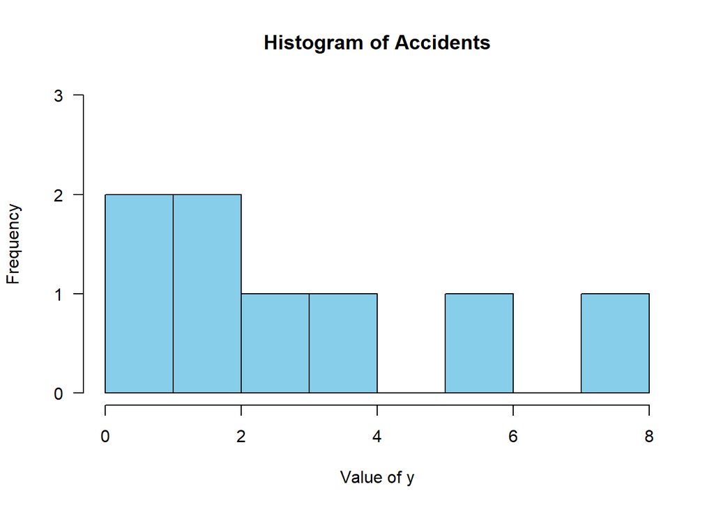

```r
hist(y,
     breaks = 8,            # Number of bins
     col = "skyblue",        # Fill color
     border = "black",       # Border color
     main = "Histogram of Accidents", # Main title
     xlab = "Value of y",    # X-axis label
     ylab = "Frequency",     # Y-axis label
     xlim = c(min(y), max(y)), # X-axis limits
     ylim = c(0, 3),         # Y-axis limits
     probability = FALSE,     # Normalize to probability density
     las = 1                  # Make labels horizontal
)
```

Additionally, some basic statistics are calculated to help the understandability of the methods performed in the next sections.

```r
mean.y <- mean(y)
std.y <- sd(y)
mean.y; std.y
```

```
## [1] 3.25
```

```
## [1] 2.659216
```

For visualizing the prior distributions of the three students, firstly, it is necessary to set their probability distribution functions. This is completed with the usage of the function `dgamma` for Bry and Claudia, while Carles assumes that all possible values for μ are equally likely and uses a flat prior, $π(μ) = 1$ for $μ > 0$. This is an improper prior because it doesn’t integrate to 1 over all possible values of $μ$, but a simulation can stil be generated based on his assumption, if the posterior generated is a proper one. After setting up the functions, their visualization takes places by providing as inputs, values of $x$ ranging from 0 to 30. To be more precise, the priors $π(μ)$ as mentioned in the statement of the exercise, refer to the information we have about the parameter $μ$ (or mostly know as $λ$) of the $Poisson$ distribution.

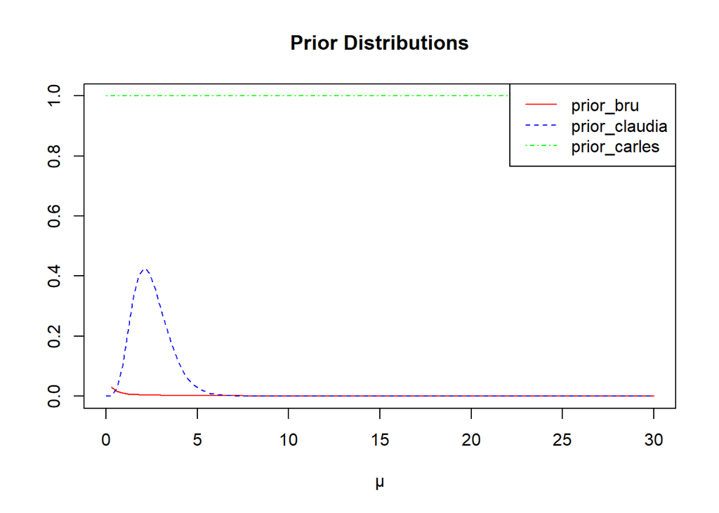

```r
# Initialize the probability densities for the three prior distributions
prior_bru <- function(x) dgamma(x, 0.01, 0.001)
prior_claudia <- function(x) dgamma(x, 6.25, 2.5)
prior_carles <- function(x) ifelse(x >= 0, 1, 0)

# Define custom colors for the distributions
bruprior_color <- "red"
claudiaprior_color <- "blue"
carlesprior_color <- "green"


par(mfrow = c(1, 1))
plot(prior_bru, xlim = c(0, 30), ylim = c(0, 1), main = "Prior Distributions",
     ylab = "", xlab = "μ", lty = 1, col = bruprior_color)
plot(prior_claudia, xlim = c(0, 30), add = TRUE, lty = 2, col = claudiaprior_color)
plot(prior_carles, xlim = c(0, 30), add = TRUE, lty = 4, col = carlesprior_color)
legend("topright", c("prior_bru", "prior_claudia", "prior_carles"),
       lty = c(1, 2, 4), col = c(bruprior_color, claudiaprior_color, carlesprior_color))
```

It can be seen that Carle’s prior is a flat prior (improper one, since it does not integrate to 1), Claudia’s distribution gives more weight to the parameter of the Poisson distribution to be between 1 and 5, although Bru’s (as it can be seen in the following figure as well), gives more weight to the values between 0 to 2 approximately.

It was necessary to visualize Bru’s prior in a more clear way. In the previous plot it is not visible due to the difference in the scales of the probability values for the three prior distributions.

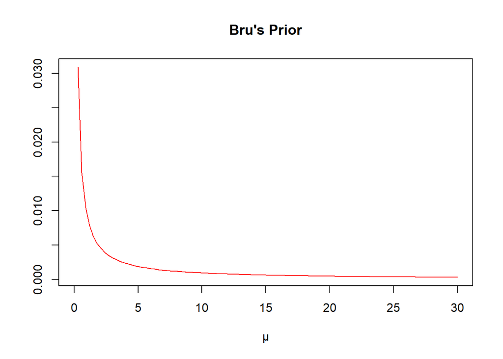

```r
plot(prior_bru, xlim=c(0,30), main = "Bru's Prior", ylab="", xlab = "μ", lty=1, col = bruprior_color)
```

## (b) Draw the likelihood function

```r
likelihood <- function(lambda) {
 lambda^sum(y)*exp(-n*lambda)
}
```

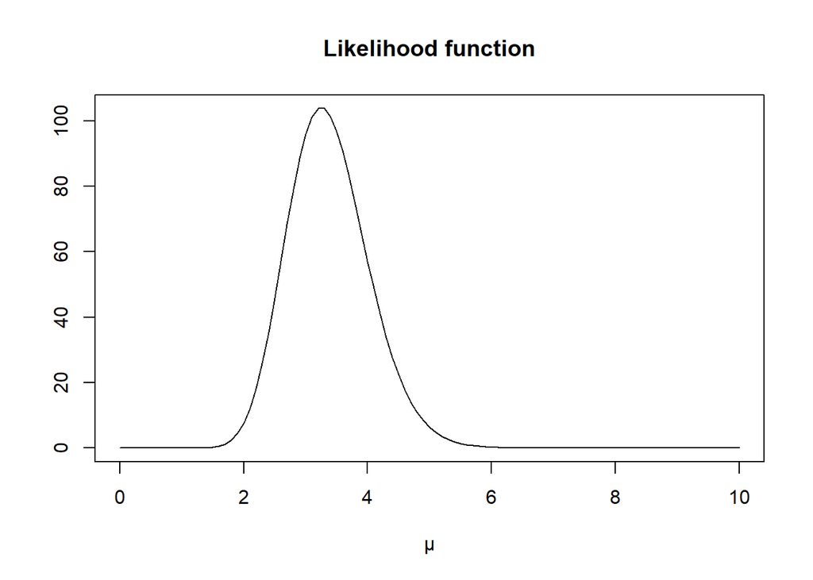

```r
plot(likelihood, xlim=c(0,10), main = "Likelihood function", ylab="", xlab = "μ",lty=1)
```

## (c) Draw the three posterior distributions in the same graph

To continue with, the plot of the three posterior distributions is taking place. From the theory and the lab classes, it is know that, when a $Poisson$ distribution is used as the probability model, and a $Gamma$ function as the prior distribution, the posterior distribution is defined as a new $Gamma$ function with parameters equal to $(a+sum(y), b+length(y))$. This has been applied in the cases of Bru and Claudia. As for Carles, again from the theory, it is known that, when a flat prior is used, meaning that the value of the prior is constant, then the posterior distribution is equal to the $Standardized Likelihood$ function. Once the functions have been defined, the generation of the plot takes place.

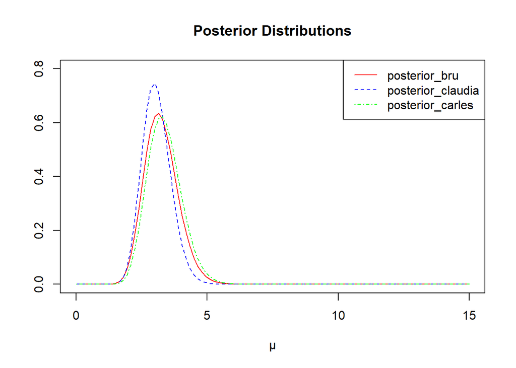

```r
#prior_bru <- function(x) dgamma(x, 0.01, 0.001)
posterior_bru <- function(x)dgamma(x, 0.01 + sum(y), 0.001 + n)

#prior_claudia <- function(x) dgamma(x, 6.25, 2.5)
posterior_claudia <- function(x)dgamma(x, 6.25 + sum(y), 2.5 + n)

#prior_carles <- function(x) ifelse(x > 0, 1, 0)
posterior_carles <- function(lambda) {
 (lambda^sum(y)*exp(-n*lambda)) /integrate(function(lambda)(lambda^sum(y)*exp(-n*lambda)), lower = 0, upper = 15)$value
}

# Define custom colors for the distributions
bruposterior_color <- "red"
claudiaposterior_color <- "blue"
carlesposterior_color <- "green"

par(mfrow = c(1, 1))
plot(posterior_bru, xlim = c(0, 15), ylim = c(0, 0.8), main = "Posterior Distributions",
     ylab = "", xlab = "μ", lty = 1, col = bruposterior_color)
plot(posterior_claudia, xlim = c(0, 15), add = TRUE, lty = 2, col = claudiaposterior_color)
plot(posterior_carles, xlim = c(0, 15), add = TRUE, lty = 4, col = carlesposterior_color)
legend("topright", c("posterior_bru", "posterior_claudia", "posterior_carles"),
       lty = c(1, 2, 4), col = c(bruposterior_color, claudiaposterior_color, carlesposterior_color))
```

The three different posterior distributions include both the prior knowledge of the three students about the parameters of the probability model, as well as the observations of the target variable they gathered.

## (d) Calculate a 90% credible interval of the number of accidents for next weekend

### For each of the three Bayesian models

In this question, the calculation of a 90% credible interval for the number of accidents is completed. In order to answer this question, instead of using an analytical approach, a simulation was performed. More specifically, for Bru and Claudia, by using the function `rgamma`, but updated with the parameters of the $Gamma$ distribution, based on the posterior distributions of the Bayesian models, we generate 100.000 estimations for the parameters of the $Poisson$ probability model. Consequently, those estimations are being used to generate 100.000 values of the posterior predictive distribution of the Bayesian Models. As for Carles, since the posterior distribution is equal to the Standardized Likelihood, we use a technique to generate 100.000 random values of `lambdas`, which overcome the acceptance probability based on the likelihood function (see `chunk: generate.lambda.samples.for.Carles`). Once those lambdas have been generated, the same approach with Bru and Claudia is being used, meaning that those 100.000 random lambdas, are feeded into a $Poisson$ generation algorithm, in order to obtain 100.000 values of Carle’s posterior predictive distribution. Finally, by using the `quantile` function, we calculate the 5% and 95% probabilities of those distributions in order to generate an interval of 90%. The results are presented below.

```r
sample_lambda <- function(num_samples) {
  lambda_samples <- numeric(num_samples)
  for (i in 1:num_samples) {
    while (TRUE) {
      lambda_candidate <- runif(1, 0, 15)  # Sample a lambda candidate

      # Calculate the acceptance probability
      acceptance_prob <- likelihood(lambda_candidate)

      # Accept the candidate with probability acceptance_prob
      if (runif(1) < acceptance_prob) {
        lambda_samples[i] <- lambda_candidate
        break  # Break out of the while loop
      }
    }
  }
  return(lambda_samples)
}
```

```r
# Set the number of simulations
num_simulations <- 100000

# Initialize lists to store the results
post_predictive_sim_bru <- vector("list", length = num_simulations)
post_predictive_sim_claudia <- vector("list", length = num_simulations)
post_predictive_sim_carles <- vector("list", length = num_simulations)

lambdas <- sample_lambda(num_simulations)

# Simulate from the three posterior distributions and calculate the predictive posterior
for (i in 1:num_simulations) {

  # Simulate from the posterior distributions
  sample_bru <- rgamma(1, shape = 0.01 + sum(y), rate = 0.001 + n)

  sample_claudia <- rgamma(1, shape = 6.25 + sum(y), rate = 2.5 + n)

  # Calculate the posterior predictive distribution using the Poisson(μ) prior
  predictive_bru <- rpois(1, lambda = sample_bru)
  predictive_claudia <- rpois(1, lambda = sample_claudia)
  predictive_carles <- rpois(1, lambda = lambdas[i])

  # Store the results
  post_predictive_sim_bru[i] <- predictive_bru
  post_predictive_sim_claudia[i] <- predictive_claudia
  post_predictive_sim_carles[i] <- predictive_carles
}
```

```r
 # Store the results
post_predictive_sim_bru <- unlist(post_predictive_sim_bru)
post_predictive_sim_claudia <- unlist(post_predictive_sim_claudia)
post_predictive_sim_carles <- unlist(post_predictive_sim_carles)
```

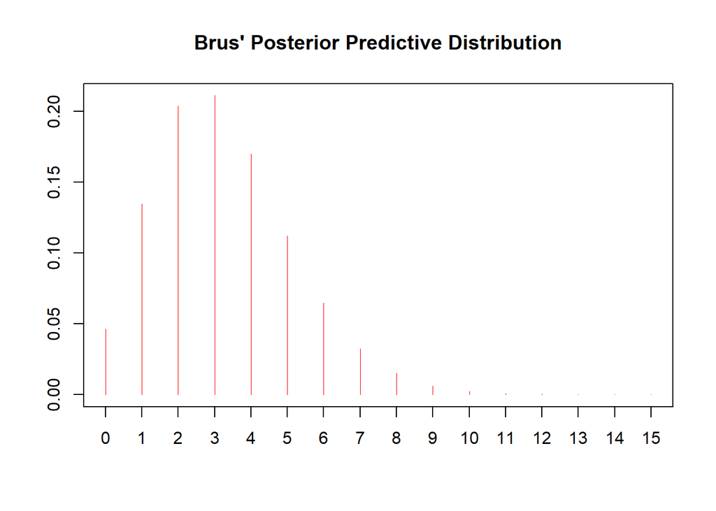

```r
par(mfrow = c(1, 1))

# Bru's Posterior Predictive Distribution
plot(table(post_predictive_sim_bru)/num_simulations, xlim=c(0, 15), ylab = "", xlab = "", col=bruposterior_color, lwd=0.5)
title("Brus' Posterior Predictive Distribution")
```

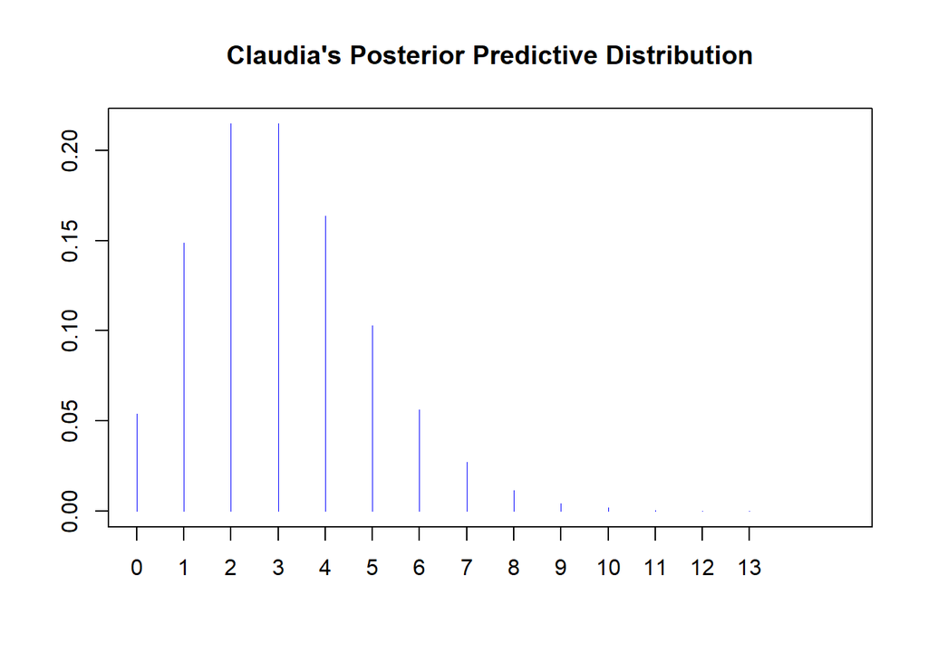

```r
# Claudia's Posterior Predictive Distribution
par(mfrow = c(1, 1))  # Reset the plot layout to one plot region
plot(table(post_predictive_sim_claudia)/num_simulations, xlim=c(0, 15), ylab = "", xlab = "", col=claudiaposterior_color, lwd=0.5)
title("Claudia's Posterior Predictive Distribution")
```

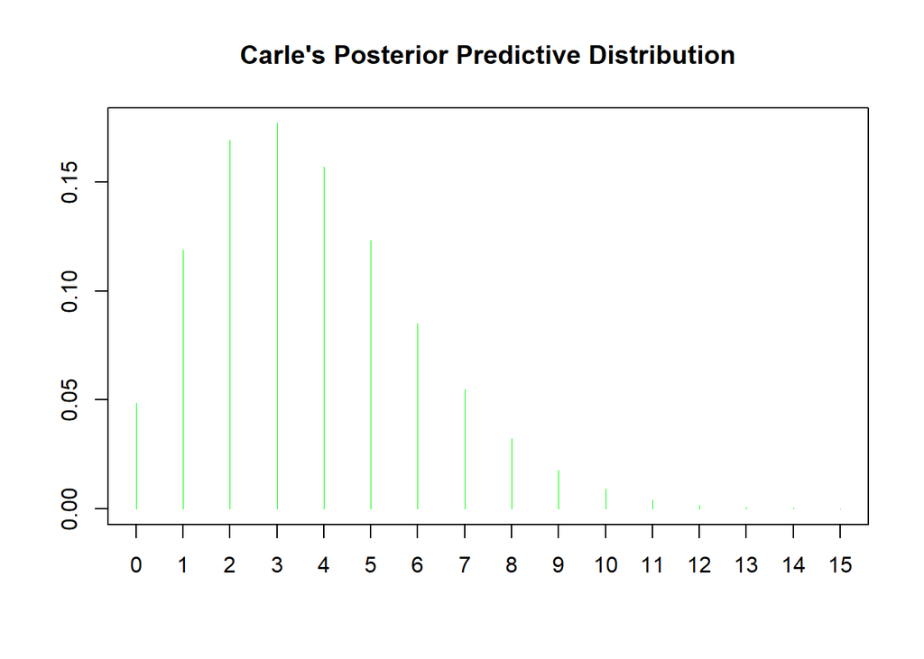

```r
# Carles's Posterior Predictive Distribution
par(mfrow = c(1, 1))  # Reset the plot layout to one plot region
plot(table(post_predictive_sim_carles)/num_simulations, xlim=c(0, 15), ylab = "", xlab = "", col=carlesposterior_color, lwd=0.5)
title("Carle's Posterior Predictive Distribution")
```

```r
quantile_levels <- c(0.05, 0.25, 0.5, 0.75, 0.95)
quantile(post_predictive_sim_claudia, quantile_levels)
```

```
##  5% 25% 50% 75% 95%
##   0   2   3   4   6
```

```r
# 5th percentile
claudia_lower_quantile <- quantile(post_predictive_sim_claudia, 0.05)

# 95th percentile
claudia_upper_quantile <- quantile(post_predictive_sim_claudia, 0.95)
```

```r
# 5th percentile
quantile(post_predictive_sim_carles, quantile_levels)
```

```
##  5% 25% 50% 75% 95%
##   1   2   3   5   8
```

```r
carles_lower_quantile <- quantile(post_predictive_sim_carles, 0.05)

# 95th percentile
carles_upper_quantile <- quantile(post_predictive_sim_carles, 0.95)
```

```r
# 5th percentile
quantile(post_predictive_sim_bru, quantile_levels)
```

```
##  5% 25% 50% 75% 95%
##   1   2   3   4   7
```

```r
bru_lower_quantile <- quantile(post_predictive_sim_bru, 0.05)

# 95th percentile
bru_upper_quantile <- quantile(post_predictive_sim_bru, 0.95)
```

```r
# Print the intervals for each vector
cat("Claudia's 90% Interval:
    [", claudia_lower_quantile, ",", claudia_upper_quantile, "]\n")
```

```
## Claudia's 90% Interval:
##     [ 0 , 6 ]
```

```r
cat("Bru's 90% Interval:
    [", bru_lower_quantile, ",", bru_upper_quantile, "]\n")
```

```
## Bru's 90% Interval:
##     [ 1 , 7 ]
```

```r
cat("Carle's 90% Interval:
    [", carles_lower_quantile, ",", carles_upper_quantile, "]\n")
```

```
## Carle's 90% Interval:
##     [ 1 , 8 ]
```